## Background

Using devices such as Jawbone Up, Nike FuelBand, and Fitbit it is now possible to collect a large amount of data about personal activity relatively inexpensively. These type of devices are part of the quantified self movement - a group of enthusiasts who take measurements about themselves regularly to improve their health, to find patterns in their behavior, or because they are tech geeks. One thing that people regularly do is quantify how much of a particular activity they do, but they rarely quantify how well they do it. In this project, the goal will be to use data from accelerometers on the belt, forearm, arm, and dumbell of 6 participants. They were asked to perform barbell lifts correctly and incorrectly in 5 different ways. More information is available from the website: http://groupware.les.inf.puc-rio.br/har. (See the section on the Weight Lifting Exercise Dataset)

## Data

The training data for this project are available here: https://d396qusza40orc.cloudfront.net/predmachlearn/pml-training.csv

The test data are available here: https://d396qusza40orc.cloudfront.net/predmachlearn/pml-testing.csv

The data for this project come from this source: http://groupware.les.inf.puc-rio.br/har.

## Objective

The goal of the project is to predict the manner in which they did the exercise. This is the “classe” variable in the training set.

## Download the training and test data

```r
trainUrl <-"https://d396qusza40orc.cloudfront.net/predmachlearn/pml-training.csv"
testUrl <- "https://d396qusza40orc.cloudfront.net/predmachlearn/pml-testing.csv"
trainFile <- "pml-training.csv"
testFile  <- "pml-testing.csv"
if (!file.exists(trainFile)) {
  download.file(trainUrl, destfile=trainFile)
}
if (!file.exists(testFile)) {
  download.file(testUrl, destfile=testFile)
}
```

## Reading and Cleaning Data, Processing and Slicing

Any operation performed on the training set ought to be replicated on the test data too.

```r
library(caret)
```

```r
library(corrplot)
library(manipulate)
library(xtable)
data <- read.csv("pml-training.csv",na.strings=c("NA","#DIV/0!",""))
testing <- read.csv("pml-testing.csv",na.strings=c("NA","#DIV/0!",""))
dim(data)
```

[1] 19622 160

```r
# remove columns woth more than 30% NAs
data1 <- data[, colSums(is.na(data)) < nrow(data) * 0.3]
test1 <- testing[, colSums(is.na(testing)) < nrow(testing) * 0.3]

# remove all Near Zero Variance variables
NZV <- nearZeroVar(data1, saveMetrics= TRUE)
data2 <- data1[,!NZV$nzv]
test2 <- test1[,!NZV$nzv]

# remove unnecessary columns like user_name and time windows
data3 <- data2[,-c(1:6)]
test3 <- test2[,-c(1:6)]

# set seed for reproducability and partition data into training and validation sets
# assign 60% of data for training and 40% for validation set
set.seed(1)
inTrain <- createDataPartition(y=data3$classe, p=0.60, list=FALSE)
training <- data3[inTrain,]
valid <- data3[-inTrain,]
```

Since Random Forest is to be used to model the data, the correlation among the features are not going to be examined, but will be plotted to see if any patterns emerge

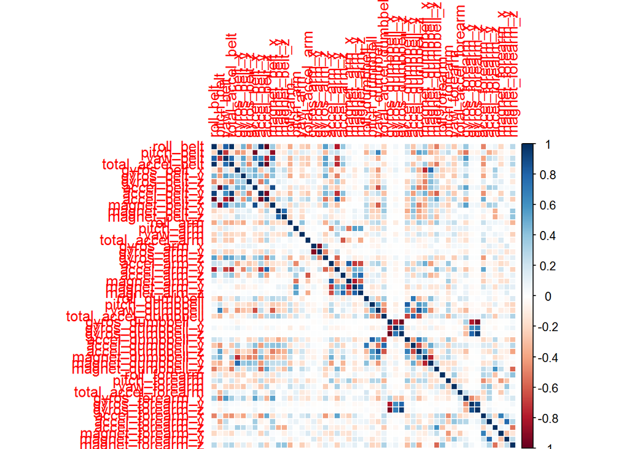

```r
# Examine correlation among features
corrPlot <- cor(training[, -53])
corrplot(corrPlot, method="color")
```

## Data Modelling and evaluating in sample error

Because of its accuracy and ability to handle large number of features, especially when the interactions between variables are unknown, flexibility to use unscaled variables and categorical variables, which reduces the need for cleaning and transforming variables, immunity from overfitting and noise, and insensitivity to correlation among the features, Random Forest is chosen to model the training data. A 4-fold Cross Validation shall be employed.

```r
rf1<- train(x=training[,-53],y=training$classe,method="rf",
                trControl=trainControl(method = "cv", number = 4),
                data=training,do.trace=F,ntree=250)

rf1
```

Random Forest

11776 samples 52 predictor 5 classes: ‘A’, ‘B’, ‘C’, ‘D’, ‘E’

No pre-processing Resampling: Cross-Validated (4 fold)

Summary of sample sizes: 8832, 8831, 8832, 8833

Resampling results across tuning parameters:

mtry Accuracy Kappa Accuracy SD Kappa SD  
2 0.9866678 0.9831326 0.001577792 0.001994828 27 0.9876870 0.9844241 0.001846084 0.002333847 52 0.9808931 0.9758283 0.005652916 0.007152936

Accuracy was used to select the optimal model using the largest value. The final value used for the model was mtry = 27.

```r
# User and Elapsed time
rf1$times
```

$everything user system elapsed 264.41 1.20 269.96

$final user system elapsed 38.85 0.09 40.07

$prediction [1] NA NA NA

```r
# Testing the model on the same data used to create it: to evaluate in sample error
pred_train_rf1 <- predict(rf1$finalModel,newdata=training)
a <- confusionMatrix(pred_train_rf1,training$classe)
print(xtable(as.matrix(a)),type="HTML")
```

|  | A | B | C | D | E |
| --- | --- | --- | --- | --- | --- |
| A | 3348 | 0 | 0 | 0 | 0 |
| B | 0 | 2279 | 0 | 0 | 0 |
| C | 0 | 0 | 2054 | 0 | 0 |
| D | 0 | 0 | 0 | 1930 | 0 |
| E | 0 | 0 | 0 | 0 | 2165 |

```r
# In Sample Error
ISE_rf1<- 100- (mean((pred_train_rf1 == training$classe)*1)*100)
ISE_rf1
```

[1] 0

```r
# Out of Sample Error Estimate
pred_valid_rf1 <- predict(rf1,valid)
table(pred_valid_rf1,valid$classe)
```

pred_valid_rf1 A B C D E A 2225 5 0 0 0 B 4 1507 5 0 1 C 2 6 1358 17 3 D 0 0 5 1268 4 E 1 0 0 1 1434

```r
OSE_rf1<-100 - (mean((pred_valid_rf1 == valid$classe)*1)*100)
OSE_rf1
```

[1] 0.6882488

```r
# Confusion Matrix
b <- confusionMatrix(valid$classe,pred_valid_rf1)
print(xtable(as.matrix(b)),type="HTML")
```

|  | A | B | C | D | E |
| --- | --- | --- | --- | --- | --- |
| A | 2225 | 4 | 2 | 0 | 1 |
| B | 5 | 1507 | 6 | 0 | 0 |
| C | 0 | 5 | 1358 | 5 | 0 |
| D | 0 | 0 | 17 | 1268 | 1 |
| E | 0 | 1 | 3 | 4 | 1434 |

## Applying the RF Data Model to test data

The ‘rf1’ model developed using the training set shall be used to predict the ‘classe’ variable for the test set.

```r
pred_test_rf1 <- predict(rf1,test3[,-53])
pred_test_rf1
```

[1] B A B A A E D B A A B C B A E E A B B B Levels: A B C D E

```r
table(pred_test_rf1)
```

pred_test_rf1 A B C D E 7 8 1 1 3

## Relative Importance of Features and parsimonius model development

Random Forest can be used to determine the relative importance if each of the features. By eliminating the least influential ones, the model could become more parsinimonious.

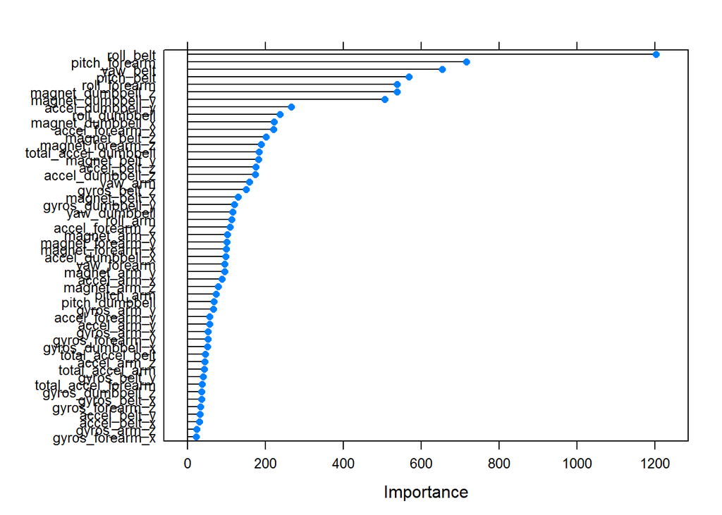

```r
# Overall relative importance

importance <- varImp(rf1, scale=FALSE)
# Importance of each feature for each of the classe outcomes
plot(importance)
```

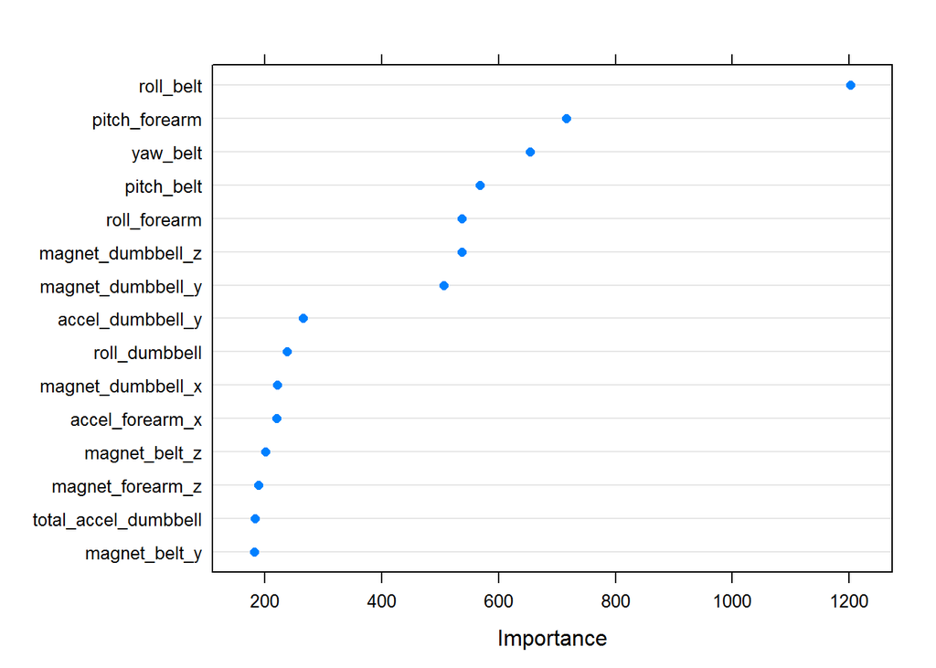

```r
dotPlot(importance, top = 15)
```

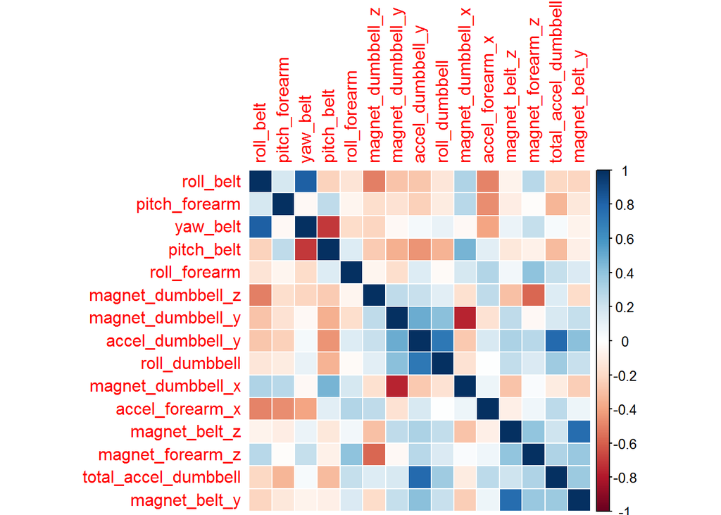

```r
# Identifying the top 15 vriables

variables <- varImp(rf1)
vars <- variables[[1]]
top.vars <- rownames(vars)[order(rowSums(vars), decreasing = TRUE)][1:15]

# Examining the correlations again
corrPlot1 <- cor(training[, top.vars])
corrplot(corrPlot1, method="color")
```

## Parsimonious Model

```r
top_rf <- train(x = training[ , top.vars], y = training$classe, method="rf",
                trControl=trainControl(method = "cv", number = 4),
                data=training,do.trace=F,ntree=250)

# Checr user and elapsed times
top_rf$times
```

$everything user system elapsed 71.33 1.14 73.71

$final user system elapsed 5.53 0.08 5.76

$prediction [1] NA NA NA

## Predictions from Parsimonious Model

```r
pred_train_top <- predict(top_rf,newdata=training)
c <- confusionMatrix(pred_train_top,training$classe)
print(xtable(as.matrix(c)),type="HTML")
```

|  | A | B | C | D | E |
| --- | --- | --- | --- | --- | --- |
| A | 3348 | 0 | 0 | 0 | 0 |
| B | 0 | 2279 | 0 | 0 | 0 |
| C | 0 | 0 | 2054 | 0 | 0 |
| D | 0 | 0 | 0 | 1930 | 0 |
| E | 0 | 0 | 0 | 0 | 2165 |

```r
# In sample error with the top 15 variables
ISE_top<- 100- (mean((pred_train_top == training$classe)*1)*100)
ISE_top
```

[1] 0

```r
pred_valid_top <- predict(top_rf,valid)
d <- confusionMatrix(pred_valid_top,valid$classe)
print(xtable(as.matrix(d)),type="HTML")
```

|  | A | B | C | D | E |
| --- | --- | --- | --- | --- | --- |
| A | 2219 | 13 | 0 | 0 | 0 |
| B | 11 | 1469 | 9 | 0 | 10 |
| C | 1 | 31 | 1352 | 21 | 4 |
| D | 1 | 5 | 7 | 1264 | 10 |
| E | 0 | 0 | 0 | 1 | 1418 |

```r
# Out of sample error with the top 15 variables
OSE_top<-100 - (mean((pred_valid_top == valid$classe)*1)*100)
OSE_top
```

[1] 1.580423

## Results for the test data set

```r
pred_test_top <- predict(top_rf,test3[,-53])
pred_test_top
```

[1] B A B A A E D B A A B C B A E E A B B B Levels: A B C D E

```r
table(pred_test_top)
```

pred_test_top A B C D E 7 8 1 1 3

## Comparing the Test set predictions using the full and parsimonious models

```r
identical(pred_test_top,pred_test_rf1)
```

[1] TRUE

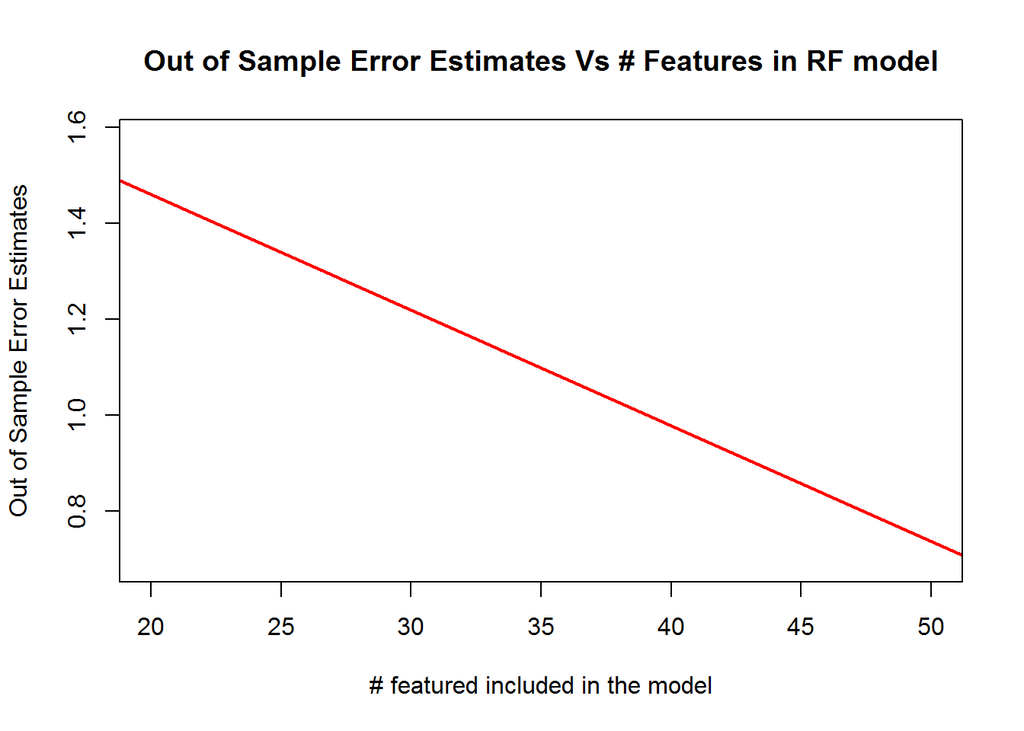

```r
plot(c(52,15),c(OSE_rf1,OSE_top),type="l",
     col=2,lwd=2,xlab="# featured included in the model",
     ylab = "Out of Sample Error Estimates",
     main= 'Out of Sample Error Estimates Vs # Features in RF model',
     xlim = c(20,50))
```

## Conclusion

Full model out of sample error estimate

```r
OSE_rf1
```

```
## [1] 0.6882488
```

Parsimonious model out of sample error estimate

```r
OSE_top
```

```
## [1] 1.580423
```

Both models gives acceptable levels of Out of Sample Error estimates. The choice of number of features to be considered could be dictated by the accuracy levels needed and/or the computing time constraints. An effective trade off can be achieved by tuning the model.